# Alzheimers Analysis

**Introduction** *Alzheimer’s disease is an irreversible, progressive brain disorder that slowly destroys memory and thinking skills and, eventually, the ability to carry out the simplest tasks. In most people with the disease—those with the late-onset type—symptoms first appear in their mid-60s.*

**The Dataset**

```r
#https://www.oasis-brains.org/files/oasis_cross-sectional.csv
library(readxl)
library(plotrix)
library(ggplot2)
library(ggcorrplot)
library(dplyr)
library(GGally)
dd <- read.csv("C:/Users/pc/Desktop/sem5/DATA PROJECT/dd.csv")
d1=na.omit(dd)

summary(d1)
```

```
##   Subject.ID           MRI.ID             Group               Visit
##  Length:354         Length:354         Length:354         Min.   :1.000
##  Class :character   Class :character   Class :character   1st Qu.:1.000
##  Mode  :character   Mode  :character   Mode  :character   Median :2.000
##                                                           Mean   :1.884
##                                                           3rd Qu.:2.000
##                                                           Max.   :5.000
##     MR.Delay          M.F                Hand                Age
##  Min.   :   0.0   Length:354         Length:354         Min.   :60.00
##  1st Qu.:   0.0   Class :character   Class :character   1st Qu.:71.00
##  Median : 559.5   Mode  :character   Mode  :character   Median :77.00
##  Mean   : 601.4                                         Mean   :77.03
##  3rd Qu.: 882.5                                         3rd Qu.:82.00
##  Max.   :2639.0                                         Max.   :98.00
##       EDUC            SES            MMSE            CDR              eTIV
##  Min.   : 6.00   Min.   :1.00   Min.   : 4.00   Min.   :0.0000   Min.   :1106
##  1st Qu.:12.00   1st Qu.:2.00   1st Qu.:27.00   1st Qu.:0.0000   1st Qu.:1358
##  Median :15.00   Median :2.00   Median :29.00   Median :0.0000   Median :1470
##  Mean   :14.70   Mean   :2.46   Mean   :27.41   Mean   :0.2712   Mean   :1490
##  3rd Qu.:16.75   3rd Qu.:3.00   3rd Qu.:30.00   3rd Qu.:0.5000   3rd Qu.:1595
##  Max.   :23.00   Max.   :5.00   Max.   :30.00   Max.   :2.0000   Max.   :2004
##       nWBV             ASF
##  Min.   :0.6440   Min.   :0.876
##  1st Qu.:0.6990   1st Qu.:1.100
##  Median :0.7290   Median :1.194
##  Mean   :0.7299   Mean   :1.194
##  3rd Qu.:0.7570   3rd Qu.:1.292
##  Max.   :0.8370   Max.   :1.587
```

```r
head(d1)
```

```
##   Subject.ID        MRI.ID       Group Visit MR.Delay M.F Hand Age EDUC SES
## 1  OAS2_0001 OAS2_0001_MR1 Nondemented     1        0   M    R  87   14   2
## 2  OAS2_0001 OAS2_0001_MR2 Nondemented     2      457   M    R  88   14   2
## 6  OAS2_0004 OAS2_0004_MR1 Nondemented     1        0   F    R  88   18   3
## 7  OAS2_0004 OAS2_0004_MR2 Nondemented     2      538   F    R  90   18   3
## 8  OAS2_0005 OAS2_0005_MR1 Nondemented     1        0   M    R  80   12   4
## 9  OAS2_0005 OAS2_0005_MR2 Nondemented     2     1010   M    R  83   12   4
##   MMSE CDR eTIV  nWBV   ASF
## 1   27 0.0 1987 0.696 0.883
## 2   30 0.0 2004 0.681 0.876
## 6   28 0.0 1215 0.710 1.444
## 7   27 0.0 1200 0.718 1.462
## 8   28 0.0 1689 0.712 1.039
## 9   29 0.5 1701 0.711 1.032
```

```r
colnames(d1)
```

```
##  [1] "Subject.ID" "MRI.ID"     "Group"      "Visit"      "MR.Delay"
##  [6] "M.F"        "Hand"       "Age"        "EDUC"       "SES"
## [11] "MMSE"       "CDR"        "eTIV"       "nWBV"       "ASF"
```

**Variable Description**

| Variable Name: | Variable Description: |
| --- | --- |
| `ID` | Identification |
| `M/F` | Gender (M if Male, F if Female) |
| `Hand` | Handedness |
| `Age` | Age in years |
| `EDUC` | Years of education |
| `SES` | Socioeconomic Status |
| `MMSE` | Mini Mental State Examination |
| `CDR` | Clinical Dementia Rating |
| `eTIV` | Estimated Total Intracranial Volume |
| `nWBV` | Normalize Whole Brain Volume |
| `ASF` | Atlas Scaling Factor |
| `Delay` | Delay |
| `Visit` | Number of visits to the doctor |
| `Group` | the state of the patient |

**Gender Distribution of the disease**

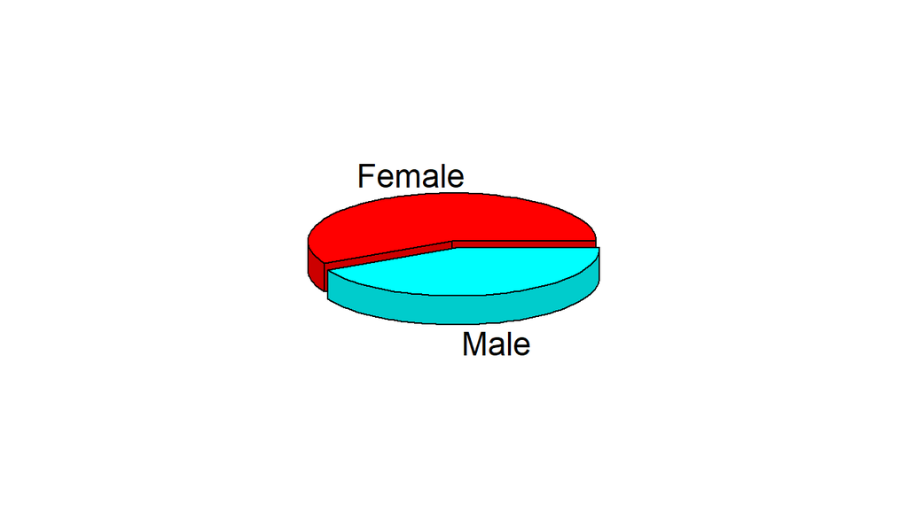

```r
library(plotrix)
kk=table(d1$M.F)
pie3D(kk,labels = c("Female","Male"),explode = 0.05)
```

*The number of female cases are more when compared to male*

**Age distribution with respect to number of cases**

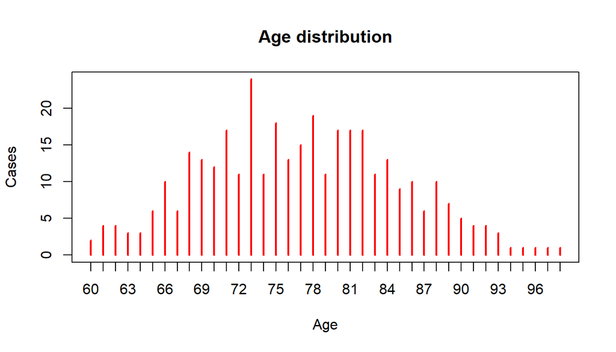

```r
k1=with(d1,table(Age))
plot(k1,main="Age distribution",ylab ="Cases",col="Red")
```

*CDR which is the clinical dementia rating is a 5-point scale used to characterize six domains of cognitive and functional performance applicable to Alzheimer disease and related dementias: Memory, Orientation, Judgment & Problem Solving, Community Affairs, Home & Hobbies, and Personal Care.*

| Scale: | Severity: |
| --- | --- |
| `ID` | Identification |
| `0` | Normal |
| `0.5` | Very Mild Dementia |
| `1` | Mild Dementia |
| `2` | Moderate Dementia |
| `=>3` | Severe Dementia |

**CDR distribution**

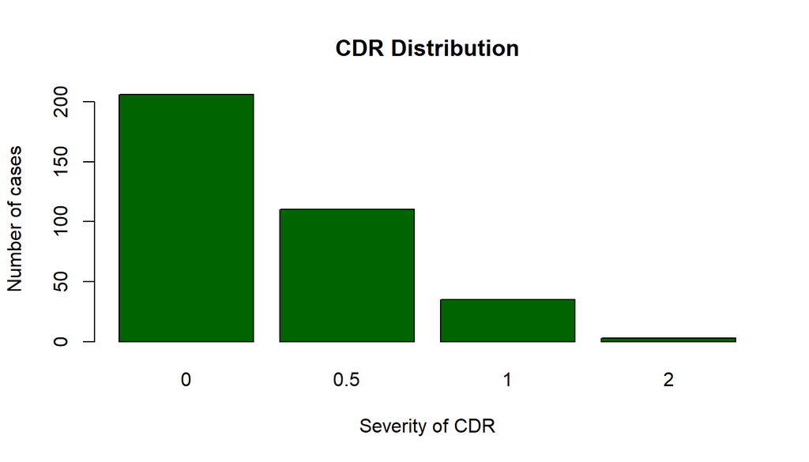

```r
barplot(table(d1$CDR),main="CDR Distribution",xlab ="Severity of CDR",ylab="Number of cases",col="dark green")
```

**CDR as per Age**

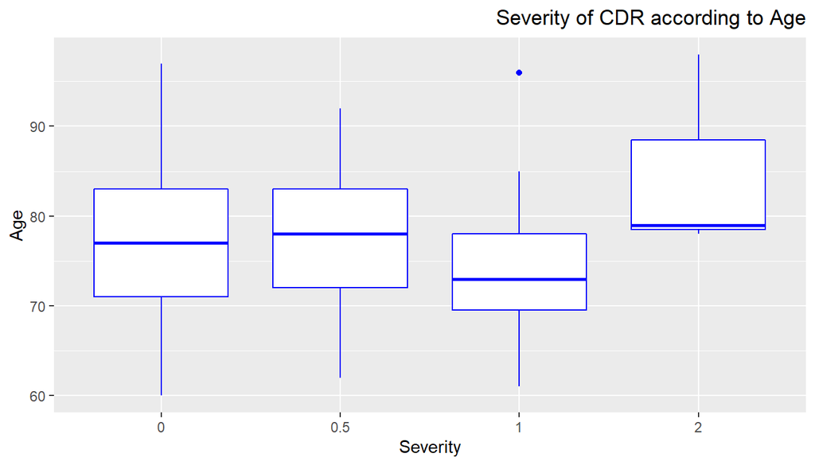

```r
ggplot(d1, aes(as.factor(CDR), Age))+
  geom_boxplot(col = "blue")+
  ggtitle("Severity of CDR according to Age")+
  xlab("Severity")+
  theme(plot.title = element_text(hjust = 1))
```

**CDR by Age and Gender**

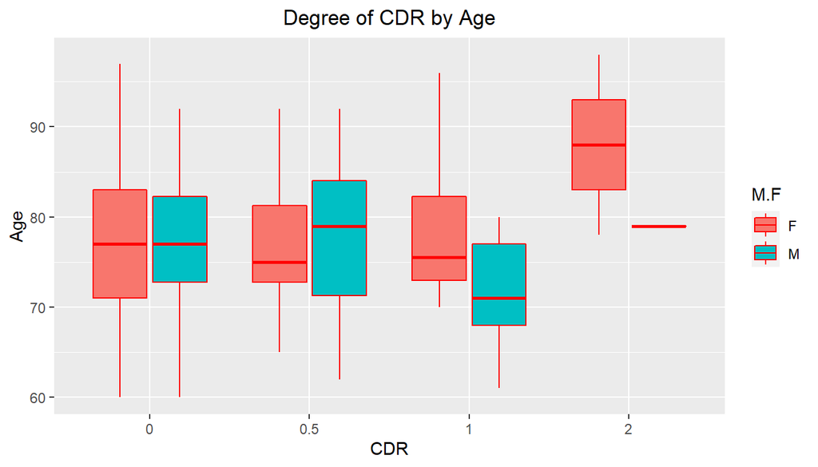

```r
ggplot(d1, aes(as.factor(CDR), Age, fill = M.F))+
  geom_boxplot(col="red")+
  ggtitle("Degree of CDR by Age")+
  xlab("CDR")+
  theme(plot.title = element_text(hjust = .5))
```

**Number of patient as per their state**

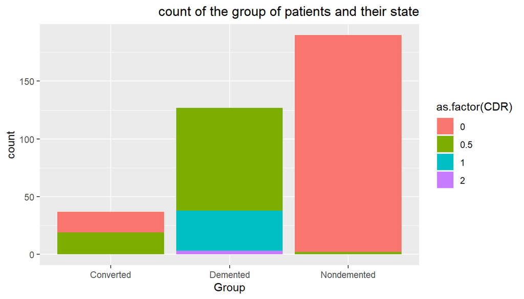

```r
ggplot(d1, aes(Group, fill = as.factor(CDR)))+
  geom_bar()+
  ggtitle("count of the group of patients and their state")+
  theme(plot.title = element_text(hjust = 1))
```

**Finding the relation between number of year in education and which group of Alzheimers**

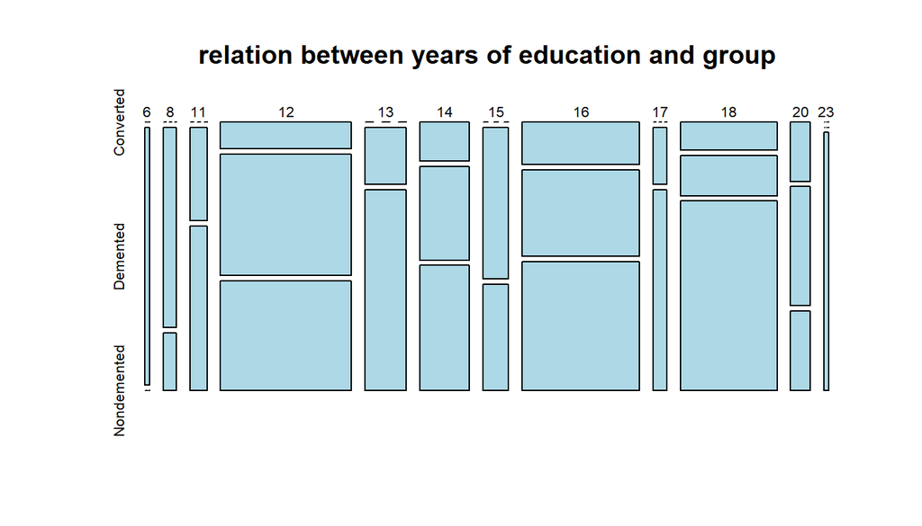

```r
plot(table(d1$EDUC,d1$Group), col='light blue', main="relation between years of education and group")
```

**Correlation between all the columns**

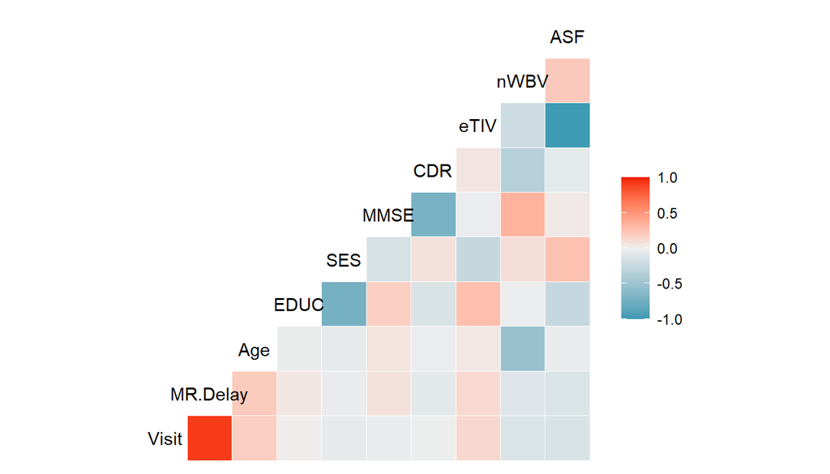

```r
library(GGally)
f<-d1
f$Subject.ID=NULL
f$Group=NULL
f$MRI.ID=NULL
f$Hand=NULL
f$M.F=NULL
ggcorr(f)
```

*The highest correlation exists between eTIV~ASF and Visits~MR.Delay*

```r
cor(d1$eTIV,d1$ASF)
```

```
## [1] -0.9890299
```

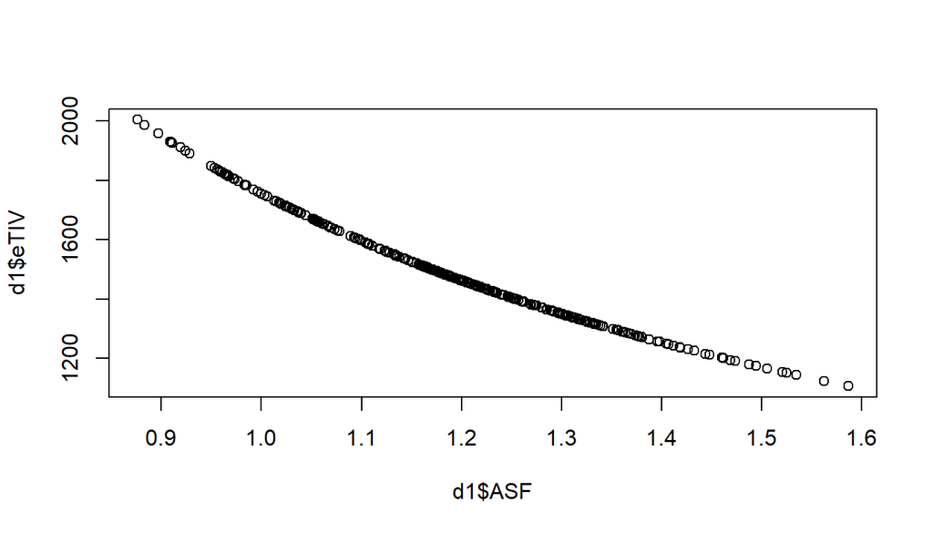

```r
plot(d1$eTIV~d1$ASF)
```

*eTIV is a estimate of maximum premorbid brain size ASF is a one-parameter scaling factor that allows for comparison of the estimated total intracranial volume*

```r
cor(d1$Visit,d1$MR.Delay)
```

```
## [1] 0.9228329
```

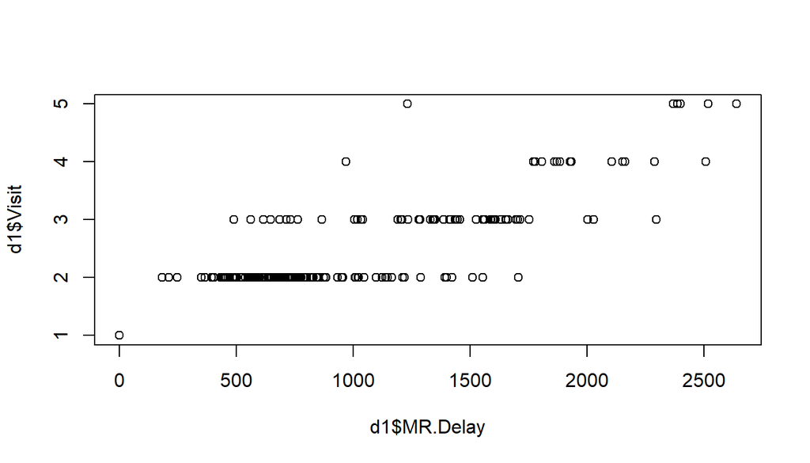

```r
plot(d1$Visit~d1$MR.Delay)
```